# Blue Rockfish

*Sebastes mystinus*

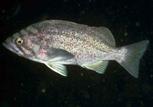

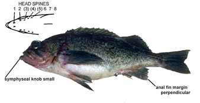

**Body color:** Bluish-black w/ darker mottling on back, paler color on sides, and grayish ventrally; fins dark. (Also see above underwater photo.)

**Peritoneum color:** light or dark **Shape between eyes:** convex

**Counts:** D:XIII,15-17, Ar:8-10, P1:17-19, GR:32-38, LLp:47-53, LLs:50-56, V:26-27

**Occurence:** Gulf of Alaska - Baja California

**Depth:** 549 meters **Size:** 53 cm **Species code:** 30360

**Similar species:**

- *Black rockfish* - anal-fin margin rounded w/ slight anterior slant; mouth larger, maxilla extends beyond midorbit; eye larger; head spine count differs; anal rays typically 7-8 (typically 9 in Blue RF); dorsal rays typically 15 (typically 16 in Blue RF)
- *Dusky rockfish* - body gray or greenish brown in Light Dusky RF,uniform dark blue in Dark Dusky RF; head spines typically absent; mouth larger, maxilla extends beyond midorbit; eye larger; anal rays typically 7-8 (typically 9 in Blue RF); dorsal rays typically 15 (typically 16 in Blue RF)
- *Yellowtail rockfish and Olive rockfish* - body dark olive; mouth larger, maxilla extends beyond midorbit; eye larger; head spine count differs
- *Widow rockfish* - anal-fin margin w/ strong posterior slant; head spine count typically differs; body dusky brown

Back to Group

**Corrections:** If you see mistakes or want to suggest changes, please create an [issue](https://github.com/zoyafuso-NOAA/RACE_Survey_App/issues) on the source repository or

*reach out to Liz Dawson (Liz.Dawson AT noaa.gov).*